# Prosper Loan Data Exploration

## Preliminary Wrangling

```python
# import all packages and set plots to be embedded inline
import pandas as pd
import numpy as np
import seaborn as sb
import matplotlib.pyplot as plt

%matplotlib inline
```

```python
#load dataset into pandas dataframe
loandata = pd.read_csv('prosperLoanData.csv')
```

```python
#broadly explore the dataset
print(loandata.shape)
print(loandata.dtypes)
loandata.head(5)
```

```
(113937, 81)
ListingKey                              object
ListingNumber                            int64
ListingCreationDate                     object
CreditGrade                             object
Term                                     int64
LoanStatus                              object
ClosedDate                              object
BorrowerAPR                            float64
BorrowerRate                           float64
LenderYield                            float64
EstimatedEffectiveYield                float64
EstimatedLoss                          float64
EstimatedReturn                        float64
ProsperRating (numeric)                float64
ProsperRating (Alpha)                   object
ProsperScore                           float64
ListingCategory (numeric)                int64
BorrowerState                           object
Occupation                              object
EmploymentStatus                        object
EmploymentStatusDuration               float64
IsBorrowerHomeowner                       bool
CurrentlyInGroup                          bool
GroupKey                                object
DateCreditPulled                        object
CreditScoreRangeLower                  float64
CreditScoreRangeUpper                  float64
FirstRecordedCreditLine                 object
CurrentCreditLines                     float64
OpenCreditLines                        float64
                                        ...
TotalProsperLoans                      float64
TotalProsperPaymentsBilled             float64
OnTimeProsperPayments                  float64
ProsperPaymentsLessThanOneMonthLate    float64
ProsperPaymentsOneMonthPlusLate        float64
ProsperPrincipalBorrowed               float64
ProsperPrincipalOutstanding            float64
ScorexChangeAtTimeOfListing            float64
```

[output cut: 8 more lines]

```
MonthlyLoanPayment                     float64
LP_CustomerPayments                    float64
LP_CustomerPrincipalPayments           float64
LP_InterestandFees                     float64
LP_ServiceFees                         float64
LP_CollectionFees                      float64
LP_GrossPrincipalLoss                  float64
LP_NetPrincipalLoss                    float64
LP_NonPrincipalRecoverypayments        float64
PercentFunded                          float64
Recommendations                          int64
InvestmentFromFriendsCount               int64
InvestmentFromFriendsAmount            float64
Investors                                int64
Length: 81, dtype: object
```

|  | ListingKey | ListingNumber | ListingCreationDate | CreditGrade | Term | LoanStatus | ClosedDate | BorrowerAPR | BorrowerRate | LenderYield | ... | LP_ServiceFees | LP_CollectionFees | LP_GrossPrincipalLoss | LP_NetPrincipalLoss | LP_NonPrincipalRecoverypayments | PercentFunded | Recommendations | InvestmentFromFriendsCount | InvestmentFromFriendsAmount | Investors |
| --- | --- | --- | --- | --- | --- | --- | --- | --- | --- | --- | --- | --- | --- | --- | --- | --- | --- | --- | --- | --- | --- |
| 0 | 1021339766868145413AB3B | 193129 | 2007-08-26 19:09:29.263000000 | C | 36 | Completed | 2009-08-14 00:00:00 | 0.16516 | 0.1580 | 0.1380 | ... | -133.18 | 0.0 | 0.0 | 0.0 | 0.0 | 1.0 | 0 | 0 | 0.0 | 258 |
| 1 | 10273602499503308B223C1 | 1209647 | 2014-02-27 08:28:07.900000000 | NaN | 36 | Current | NaN | 0.12016 | 0.0920 | 0.0820 | ... | 0.00 | 0.0 | 0.0 | 0.0 | 0.0 | 1.0 | 0 | 0 | 0.0 | 1 |
| 2 | 0EE9337825851032864889A | 81716 | 2007-01-05 15:00:47.090000000 | HR | 36 | Completed | 2009-12-17 00:00:00 | 0.28269 | 0.2750 | 0.2400 | ... | -24.20 | 0.0 | 0.0 | 0.0 | 0.0 | 1.0 | 0 | 0 | 0.0 | 41 |
| 3 | 0EF5356002482715299901A | 658116 | 2012-10-22 11:02:35.010000000 | NaN | 36 | Current | NaN | 0.12528 | 0.0974 | 0.0874 | ... | -108.01 | 0.0 | 0.0 | 0.0 | 0.0 | 1.0 | 0 | 0 | 0.0 | 158 |
| 4 | 0F023589499656230C5E3E2 | 909464 | 2013-09-14 18:38:39.097000000 | NaN | 36 | Current | NaN | 0.24614 | 0.2085 | 0.1985 | ... | -60.27 | 0.0 | 0.0 | 0.0 | 0.0 | 1.0 | 0 | 0 | 0.0 | 20 |

5 rows × 81 columns

```python
#duplicate the data and work with clean copy
loandata_clean = loandata.copy()
```

```python
#drop rows with irrelevant data which are mostly incomplete
loandata_clean = loandata_clean.drop(['TotalProsperLoans', 'TotalProsperPaymentsBilled', 'OnTimeProsperPayments', 'ProsperPaymentsLessThanOneMonthLate', 'ProsperPaymentsOneMonthPlusLate', 'ProsperPrincipalBorrowed', 'ProsperPrincipalOutstanding', 'ScorexChangeAtTimeOfListing', 'LoanFirstDefaultedCycleNumber'], axis=1)
print(loandata_clean.shape)
```

```
(113937, 72)
```

```python
#convert date columns to correct data type - date/time
loandata_clean[['ListingCreationDate', 'ClosedDate', 'DateCreditPulled','LoanOriginationDate']] = loandata_clean[['ListingCreationDate', 'ClosedDate', 'DateCreditPulled','LoanOriginationDate']].apply(pd.to_datetime)
print(loandata_clean.dtypes)
```

```
ListingKey                                    object
ListingNumber                                  int64
ListingCreationDate                   datetime64[ns]
CreditGrade                                   object
Term                                           int64
LoanStatus                                    object
ClosedDate                            datetime64[ns]
BorrowerAPR                                  float64
BorrowerRate                                 float64
LenderYield                                  float64
EstimatedEffectiveYield                      float64
EstimatedLoss                                float64
EstimatedReturn                              float64
ProsperRating (numeric)                      float64
ProsperRating (Alpha)                         object
ProsperScore                                 float64
ListingCategory (numeric)                      int64
BorrowerState                                 object
Occupation                                    object
EmploymentStatus                              object
EmploymentStatusDuration                     float64
IsBorrowerHomeowner                             bool
CurrentlyInGroup                                bool
GroupKey                                      object
DateCreditPulled                      datetime64[ns]
CreditScoreRangeLower                        float64
CreditScoreRangeUpper                        float64
FirstRecordedCreditLine                       object
CurrentCreditLines                           float64
OpenCreditLines                              float64
                                           ...
AvailableBankcardCredit                      float64
TotalTrades                                  float64
TradesNeverDelinquent (percentage)           float64
TradesOpenedLast6Months                      float64
DebtToIncomeRatio                            float64
IncomeRange                                   object
IncomeVerifiable                                bool
StatedMonthlyIncome                          float64
LoanKey                                       object
LoanCurrentDaysDelinquent                      int64
LoanMonthsSinceOrigination                     int64
LoanNumber                                     int64
LoanOriginalAmount                             int64
LoanOriginationDate                   datetime64[ns]
LoanOriginationQuarter                        object
MemberKey                                     object
MonthlyLoanPayment                           float64
LP_CustomerPayments                          float64
LP_CustomerPrincipalPayments                 float64
LP_InterestandFees                           float64
LP_ServiceFees                               float64
LP_CollectionFees                            float64
LP_GrossPrincipalLoss                        float64
LP_NetPrincipalLoss                          float64
LP_NonPrincipalRecoverypayments              float64
PercentFunded                                float64
Recommendations                                int64
InvestmentFromFriendsCount                     int64
InvestmentFromFriendsAmount                  float64
Investors                                      int64
Length: 72, dtype: object
```

```python
#confirm all rows have no duplicates
loandata_clean.duplicated().sum()
```

```
0
```

A visual inspection of the dataset shows that the columns CreditGrade and ProsperRating (Alpha) are both ratings of the loans but were done pre and post 2009 respectively. I will merge both columns to so there is complete alpha rating data for all listings and for proper analysis.

```python
#replace all nan values in both columns with nothing
loandata_clean['CreditGrade'] = loandata_clean['CreditGrade'].replace(np.NaN, '', regex=True)
```

```python
loandata_clean['ProsperRating (Alpha)'] = loandata_clean['ProsperRating (Alpha)'].replace(np.NaN, '', regex=True)
loandata_clean.head()
```

|  | ListingKey | ListingNumber | ListingCreationDate | CreditGrade | Term | LoanStatus | ClosedDate | BorrowerAPR | BorrowerRate | LenderYield | ... | LP_ServiceFees | LP_CollectionFees | LP_GrossPrincipalLoss | LP_NetPrincipalLoss | LP_NonPrincipalRecoverypayments | PercentFunded | Recommendations | InvestmentFromFriendsCount | InvestmentFromFriendsAmount | Investors |
| --- | --- | --- | --- | --- | --- | --- | --- | --- | --- | --- | --- | --- | --- | --- | --- | --- | --- | --- | --- | --- | --- |
| 0 | 1021339766868145413AB3B | 193129 | 2007-08-26 19:09:29.263 | C | 36 | Completed | 2009-08-14 | 0.16516 | 0.1580 | 0.1380 | ... | -133.18 | 0.0 | 0.0 | 0.0 | 0.0 | 1.0 | 0 | 0 | 0.0 | 258 |
| 1 | 10273602499503308B223C1 | 1209647 | 2014-02-27 08:28:07.900 |  | 36 | Current | NaT | 0.12016 | 0.0920 | 0.0820 | ... | 0.00 | 0.0 | 0.0 | 0.0 | 0.0 | 1.0 | 0 | 0 | 0.0 | 1 |
| 2 | 0EE9337825851032864889A | 81716 | 2007-01-05 15:00:47.090 | HR | 36 | Completed | 2009-12-17 | 0.28269 | 0.2750 | 0.2400 | ... | -24.20 | 0.0 | 0.0 | 0.0 | 0.0 | 1.0 | 0 | 0 | 0.0 | 41 |
| 3 | 0EF5356002482715299901A | 658116 | 2012-10-22 11:02:35.010 |  | 36 | Current | NaT | 0.12528 | 0.0974 | 0.0874 | ... | -108.01 | 0.0 | 0.0 | 0.0 | 0.0 | 1.0 | 0 | 0 | 0.0 | 158 |
| 4 | 0F023589499656230C5E3E2 | 909464 | 2013-09-14 18:38:39.097 |  | 36 | Current | NaT | 0.24614 | 0.2085 | 0.1985 | ... | -60.27 | 0.0 | 0.0 | 0.0 | 0.0 | 1.0 | 0 | 0 | 0.0 | 20 |

5 rows × 72 columns

```python
#In order to see all columns and confirm the above action set pandas to display all columns
pd.pandas.set_option('display.max_columns', None)
loandata_clean.head()
```

|  | ListingKey | ListingNumber | ListingCreationDate | CreditGrade | Term | LoanStatus | ClosedDate | BorrowerAPR | BorrowerRate | LenderYield | EstimatedEffectiveYield | EstimatedLoss | EstimatedReturn | ProsperRating (numeric) | ProsperRating (Alpha) | ProsperScore | ListingCategory (numeric) | BorrowerState | Occupation | EmploymentStatus | EmploymentStatusDuration | IsBorrowerHomeowner | CurrentlyInGroup | GroupKey | DateCreditPulled | CreditScoreRangeLower | CreditScoreRangeUpper | FirstRecordedCreditLine | CurrentCreditLines | … |
| --- | --- | --- | --- | --- | --- | --- | --- | --- | --- | --- | --- | --- | --- | --- | --- | --- | --- | --- | --- | --- | --- | --- | --- | --- | --- | --- | --- | --- | --- | --- |
| 0 | 1021339766868145413AB3B | 193129 | 2007-08-26 19:09:29.263 | C | 36 | Completed | 2009-08-14 | 0.16516 | 0.1580 | 0.1380 | NaN | NaN | NaN | NaN |  | NaN | 0 | CO | Other | Self-employed | 2.0 | True | True | NaN | 2007-08-26 18:41:46.780 | 640.0 | 659.0 | 2001-10-11 00:00:00 | 5.0 | … |
| 1 | 10273602499503308B223C1 | 1209647 | 2014-02-27 08:28:07.900 |  | 36 | Current | NaT | 0.12016 | 0.0920 | 0.0820 | 0.07960 | 0.0249 | 0.05470 | 6.0 | A | 7.0 | 2 | CO | Professional | Employed | 44.0 | False | False | NaN | 2014-02-27 08:28:14.000 | 680.0 | 699.0 | 1996-03-18 00:00:00 | 14.0 | … |
| 2 | 0EE9337825851032864889A | 81716 | 2007-01-05 15:00:47.090 | HR | 36 | Completed | 2009-12-17 | 0.28269 | 0.2750 | 0.2400 | NaN | NaN | NaN | NaN |  | NaN | 0 | GA | Other | Not available | NaN | False | True | 783C3371218786870A73D20 | 2007-01-02 14:09:10.060 | 480.0 | 499.0 | 2002-07-27 00:00:00 | NaN | … |
| 3 | 0EF5356002482715299901A | 658116 | 2012-10-22 11:02:35.010 |  | 36 | Current | NaT | 0.12528 | 0.0974 | 0.0874 | 0.08490 | 0.0249 | 0.06000 | 6.0 | A | 9.0 | 16 | GA | Skilled Labor | Employed | 113.0 | True | False | NaN | 2012-10-22 11:02:32.000 | 800.0 | 819.0 | 1983-02-28 00:00:00 | 5.0 | … |
| 4 | 0F023589499656230C5E3E2 | 909464 | 2013-09-14 18:38:39.097 |  | 36 | Current | NaT | 0.24614 | 0.2085 | 0.1985 | 0.18316 | 0.0925 | 0.09066 | 3.0 | D | 4.0 | 2 | MN | Executive | Employed | 44.0 | True | False | NaN | 2013-09-14 18:38:44.000 | 680.0 | 699.0 | 2004-02-20 00:00:00 | 19.0 | … |

```python
#merge data from CreditGrade and ProsperRating (alpha) into new column LoanRating
loandata_clean["LoanRating"] = loandata_clean['CreditGrade'] + loandata_clean['ProsperRating (Alpha)']
loandata_clean.head()
```

|  | ListingKey | ListingNumber | ListingCreationDate | CreditGrade | Term | LoanStatus | ClosedDate | BorrowerAPR | BorrowerRate | LenderYield | EstimatedEffectiveYield | EstimatedLoss | EstimatedReturn | ProsperRating (numeric) | ProsperRating (Alpha) | ProsperScore | ListingCategory (numeric) | BorrowerState | Occupation | EmploymentStatus | EmploymentStatusDuration | IsBorrowerHomeowner | CurrentlyInGroup | GroupKey | DateCreditPulled | CreditScoreRangeLower | CreditScoreRangeUpper | FirstRecordedCreditLine | CurrentCreditLines | … |
| --- | --- | --- | --- | --- | --- | --- | --- | --- | --- | --- | --- | --- | --- | --- | --- | --- | --- | --- | --- | --- | --- | --- | --- | --- | --- | --- | --- | --- | --- | --- |
| 0 | 1021339766868145413AB3B | 193129 | 2007-08-26 19:09:29.263 | C | 36 | Completed | 2009-08-14 | 0.16516 | 0.1580 | 0.1380 | NaN | NaN | NaN | NaN |  | NaN | 0 | CO | Other | Self-employed | 2.0 | True | True | NaN | 2007-08-26 18:41:46.780 | 640.0 | 659.0 | 2001-10-11 00:00:00 | 5.0 | … |
| 1 | 10273602499503308B223C1 | 1209647 | 2014-02-27 08:28:07.900 |  | 36 | Current | NaT | 0.12016 | 0.0920 | 0.0820 | 0.07960 | 0.0249 | 0.05470 | 6.0 | A | 7.0 | 2 | CO | Professional | Employed | 44.0 | False | False | NaN | 2014-02-27 08:28:14.000 | 680.0 | 699.0 | 1996-03-18 00:00:00 | 14.0 | … |
| 2 | 0EE9337825851032864889A | 81716 | 2007-01-05 15:00:47.090 | HR | 36 | Completed | 2009-12-17 | 0.28269 | 0.2750 | 0.2400 | NaN | NaN | NaN | NaN |  | NaN | 0 | GA | Other | Not available | NaN | False | True | 783C3371218786870A73D20 | 2007-01-02 14:09:10.060 | 480.0 | 499.0 | 2002-07-27 00:00:00 | NaN | … |
| 3 | 0EF5356002482715299901A | 658116 | 2012-10-22 11:02:35.010 |  | 36 | Current | NaT | 0.12528 | 0.0974 | 0.0874 | 0.08490 | 0.0249 | 0.06000 | 6.0 | A | 9.0 | 16 | GA | Skilled Labor | Employed | 113.0 | True | False | NaN | 2012-10-22 11:02:32.000 | 800.0 | 819.0 | 1983-02-28 00:00:00 | 5.0 | … |
| 4 | 0F023589499656230C5E3E2 | 909464 | 2013-09-14 18:38:39.097 |  | 36 | Current | NaT | 0.24614 | 0.2085 | 0.1985 | 0.18316 | 0.0925 | 0.09066 | 3.0 | D | 4.0 | 2 | MN | Executive | Employed | 44.0 | True | False | NaN | 2013-09-14 18:38:44.000 | 680.0 | 699.0 | 2004-02-20 00:00:00 | 19.0 | … |

### What is the structure of your dataset?

There are 113,937 rows in the dataset with 73 features(after cleaning, 81 pre cleaning). The variables are a mix of alpha and numeric. Most of the data is shared into pre-2009 and post-2009

### What is/are the main feature(s) of interest in your dataset?

I'm interested in knowing the top reasons people took loans and how their employment status/salary influenced their decision to borrow and these are the main features of interest:

### What features in the dataset do you think will help support your investigation into your feature(s) of interest?

- **IncomeRange** The income range of the borrower at the time the listing was created.
- **StatedMonthlyIncome** The monthly income the borrower stated at the time the listing was created.
- **Occupation** The Occupation selected by the Borrower at the time they created the listing.
- **EmploymentStatus** The employment status of the borrower at the time they posted the listing.
- **BorrowerAPR** The Borrower's Annual Percentage Rate (APR) for the loan.
- **BorrowerRate** The Borrower's interest rate for this loan.
- **LenderYield** The Lender yield on the loan. Lender yield is equal to the interest rate on the loan less the servicing fee.
- **Term** The length of the loan expressed in months.
- **LoanOriginationDate** The date the loan was originated.
- **CurrentDelinquencies** Number of accounts delinquent at the time the credit profile was pulled.
- **Investors** The number of investors that funded the loan.

## Univariate Exploration

Let us begin with one of the most important variables, LoanOriginalAmount. **How is the loan amount distributed across all borrowers?**

```python
def histplot(x,y,**kwargs):
    plt.hist(data = loandata_clean, x = x, bins = bins, color="goldenrod", ec="gray")
```

```
Text(0.5,1,'Distribution of loaned amount')
```

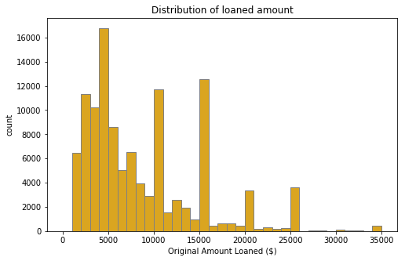

```python
#standard histogram plot
binsize = 1000
bins = np.arange(0, loandata_clean['LoanOriginalAmount'].max()+binsize, binsize)
plt.figure(figsize=[8,5])
x='LoanOriginalAmount'

histplot(x,bins)

plt.xlabel( 'Original Amount Loaned ($)')
plt.ylabel('count')
plt.title('Distribution of loaned amount')
```

```python
#since the above is somewhat skewed put in a log scale for better distribution
#first check the min and max log values
np.log10(loandata_clean['LoanOriginalAmount'].describe())
```

```
count    5.056665
mean     3.921011
std      3.795588
min      3.000000
25%      3.602060
50%      3.812913
75%      4.079181
max      4.544068
Name: LoanOriginalAmount, dtype: float64
```

```
Text(0.5,1,'Distribution of loaned amount')
```

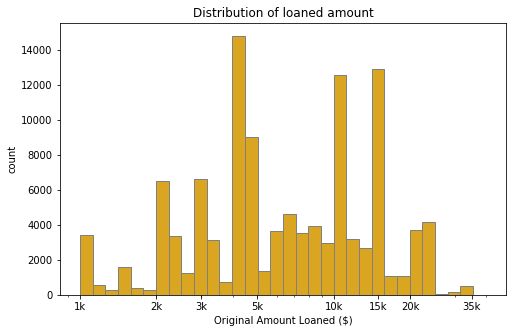

```python
log_binsize = 0.5
bins = 10 ** np.arange(3,4.6+0.05,0.05)
plt.figure(figsize=[8,5])

histplot(x,bins)

plt.xscale('log')
plt.xticks([1e3, 2e3,3e3, 5e3,1e4,1.5e4, 2e4, 3.5e4], ['1k','2k','3k','5k','10k','15k','20k','35k'])
plt.xlabel( 'Original Amount Loaned ($)')
plt.ylabel('count')
plt.title('Distribution of loaned amount')
```

The Original amount loaned peaks around \$4,500. We can see highs at about \\$11,000 and \$15,000. There is no smooth progression but there is quite a concentration on figures between \\$5,000 and \$15,000

Next, is the exploration of the EmploymentStatus column. This column has names which can be grouped together: Full-time, Part-time and self-employed are forms of employment so will be grouped with employed while other aliases will be grouped together. Only Retired will remain with no addition or subtraction. **Do the unemployed take loans at all?**

```python
#use the replace function to switch out the names
loandata_clean.replace(to_replace = ['Full-time','Part-time','Self-employed'], value = 'Employed', inplace=True)
loandata_clean.replace(to_replace = ['Not employed'], value = 'Unemployed', inplace=True)
loandata_clean.replace(to_replace = ['Not available',''], value = 'Other', inplace=True)
```

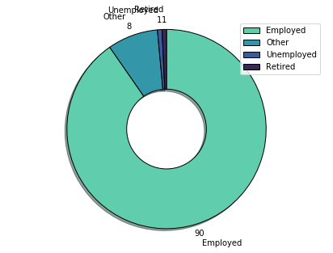

```python
sorted_counts = loandata_clean['EmploymentStatus'].value_counts()
label = sorted_counts.index
mycolor = sb.color_palette("mako_r",n_colors=4)
plt.figure(figsize=[7,5])
plt.pie(sorted_counts, labels = label,colors = mycolor, startangle = 90,
      counterclock = False,autopct='%1.0f',pctdistance=1.1,labeldistance=1.2, shadow=True, wedgeprops = {'width':0.6, 'edgecolor':'black'});

plt.axis('equal')
plt.legend(label)
```

From the donut chart, it is clear that most of the borrowers have a source of income

Since most of the borrowers are employed **What is their income range?**

```
Text(0.5,1,'No of Listings per Income Range')
```

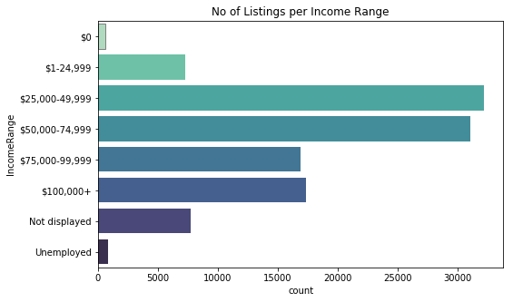

```python
mycolor = sb.color_palette("mako_r",n_colors=9)

plt.figure(figsize=[8,5])

#order the ratings in descending order
#rating_counts = loandata_clean['IncomeRange'].value_counts()
IncomeRange_order = ['$0','$1-24,999','$25,000-49,999','$50,000-74,999','$75,000-99,999','$100,000+','Not displayed','Unemployed']

#plot bar chart
sb.countplot(data = loandata_clean, y = 'IncomeRange',palette = mycolor, edgecolor ='gray',order=IncomeRange_order)
plt.title('No of Listings per Income Range')
```

Prosper rating indicates the associated level of risk with the listing with AA being the lowest risk and HR the highest risk. **What is the most awarded credit/propser rating?**

```
Text(0.5,1,'Borrowers count by Loan Rating')
```

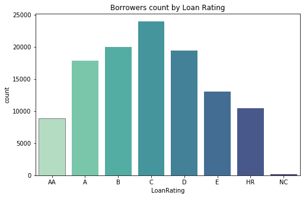

```python
mycolor = sb.color_palette("mako_r",n_colors=10)
plt.figure(figsize=[8,5])

#order the ratings in descending order
LoanRating_order = ['AA', 'A', 'B', 'C','D', 'E', 'HR','NC']

#plot bar chart
sb.countplot(data = loandata_clean, x = 'LoanRating',palette = mycolor,edgecolor ='gray', order = LoanRating_order)
plt.title('Borrowers count by Loan Rating')
```

The results show the highest rating is C which is neither the highest nor the lowest risk. However it can also be noted that listings with very low risk(AA) are infrequent.

**Do borrowers really pay back their loans?** Here we explore the LoanStatus to see that.

```python
#first order the values to return in descending order
status_counts = loandata_clean['LoanStatus'].value_counts()
LoanStatus_order = status_counts.index
```

```
Text(0.5,1,'Borrowers current Status of Loans')
```

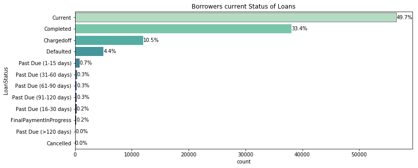

```python
#print the proportion of the bars
mycolor = sb.color_palette("mako_r",n_colors=10)
plt.figure(figsize=[12,5])

sb.countplot(data=loandata_clean, y='LoanStatus', palette=mycolor,edgecolor ='gray',order=LoanStatus_order);

#return the sum of not-null values in the Loan Status column
n_loandata_clean = loandata_clean['LoanStatus'].value_counts().sum()

for i in range(status_counts.shape[0]):
    count = status_counts[i]
    pct_string = '{:0.1f}%'.format(100*count/n_loandata_clean)
    plt.text(count+1,i,pct_string,va='center')

plt.title('Borrowers current Status of Loans')
```

Most of the loan terms are still running so this question cannot be conclusively answered. Chargeoff means that the lender has written the account off as a loss. Loan is considered defaulted when the borrower does not pay back as agreed.

The ListingCategory shows the reason for which the borrower took the loan. However this column contains only numeric values. These values will be replaced with the items the numbers represent but first the data type of that column(int64) must be converted to string. The actual ListingCategory column will be duplicated and converted as required, the original column is retained for possible analysis later. Let us explore and see **what borrowers take loan for the most?**

```python
#duplicate the column
loandata_clean['ListingCategory'] = loandata_clean.loc [:,'ListingCategory (numeric)']
#confirm new column
loandata_clean.head(2)
```

|  | ListingKey | ListingNumber | ListingCreationDate | CreditGrade | Term | LoanStatus | ClosedDate | BorrowerAPR | BorrowerRate | LenderYield | EstimatedEffectiveYield | EstimatedLoss | EstimatedReturn | ProsperRating (numeric) | ProsperRating (Alpha) | ProsperScore | ListingCategory (numeric) | BorrowerState | Occupation | EmploymentStatus | EmploymentStatusDuration | IsBorrowerHomeowner | CurrentlyInGroup | GroupKey | DateCreditPulled | CreditScoreRangeLower | CreditScoreRangeUpper | FirstRecordedCreditLine | CurrentCreditLines | … |
| --- | --- | --- | --- | --- | --- | --- | --- | --- | --- | --- | --- | --- | --- | --- | --- | --- | --- | --- | --- | --- | --- | --- | --- | --- | --- | --- | --- | --- | --- | --- |
| 0 | 1021339766868145413AB3B | 193129 | 2007-08-26 19:09:29.263 | C | 36 | Completed | 2009-08-14 | 0.16516 | 0.158 | 0.138 | NaN | NaN | NaN | NaN | Other | NaN | 0 | CO | Other | Employed | 2.0 | True | True | NaN | 2007-08-26 18:41:46.780 | 640.0 | 659.0 | 2001-10-11 00:00:00 | 5.0 | … |
| 1 | 10273602499503308B223C1 | 1209647 | 2014-02-27 08:28:07.900 | Other | 36 | Current | NaT | 0.12016 | 0.092 | 0.082 | 0.0796 | 0.0249 | 0.0547 | 6.0 | A | 7.0 | 2 | CO | Professional | Employed | 44.0 | False | False | NaN | 2014-02-27 08:28:14.000 | 680.0 | 699.0 | 1996-03-18 00:00:00 | 14.0 | … |

```python
#Replace the numeric listing catergory with the items the numbers represent
list = {0: 'Not Available',1:'Debt Consolidation',2:'Home improvement',3:'Business',4:'Personal Loan',5:'Student Use',
        6:'Auto',7:'Other',8:'Baby&Adoption',9:'Boat',10:'Cosmetic Procedure',11:'Engagement Ring',12:'Green Loans',
        13:'Household Expenses',14:'Large Purchases',15:'Medical/Dental',16:'Motorcycle',17:'RV',18:'Taxes',19:'Vacation',
        20:'Wedding Loans'}
loandata_clean["ListingCategory"] = loandata_clean["ListingCategory (numeric)"].map(list)
loandata_clean.head()
```

|  | ListingKey | ListingNumber | ListingCreationDate | CreditGrade | Term | LoanStatus | ClosedDate | BorrowerAPR | BorrowerRate | LenderYield | EstimatedEffectiveYield | EstimatedLoss | EstimatedReturn | ProsperRating (numeric) | ProsperRating (Alpha) | ProsperScore | ListingCategory (numeric) | BorrowerState | Occupation | EmploymentStatus | EmploymentStatusDuration | IsBorrowerHomeowner | CurrentlyInGroup | GroupKey | DateCreditPulled | CreditScoreRangeLower | CreditScoreRangeUpper | FirstRecordedCreditLine | CurrentCreditLines | … |
| --- | --- | --- | --- | --- | --- | --- | --- | --- | --- | --- | --- | --- | --- | --- | --- | --- | --- | --- | --- | --- | --- | --- | --- | --- | --- | --- | --- | --- | --- | --- |
| 0 | 1021339766868145413AB3B | 193129 | 2007-08-26 19:09:29.263 | C | 36 | Completed | 2009-08-14 | 0.16516 | 0.1580 | 0.1380 | NaN | NaN | NaN | NaN | Other | NaN | 0 | CO | Other | Employed | 2.0 | True | True | NaN | 2007-08-26 18:41:46.780 | 640.0 | 659.0 | 2001-10-11 00:00:00 | 5.0 | … |
| 1 | 10273602499503308B223C1 | 1209647 | 2014-02-27 08:28:07.900 | Other | 36 | Current | NaT | 0.12016 | 0.0920 | 0.0820 | 0.07960 | 0.0249 | 0.05470 | 6.0 | A | 7.0 | 2 | CO | Professional | Employed | 44.0 | False | False | NaN | 2014-02-27 08:28:14.000 | 680.0 | 699.0 | 1996-03-18 00:00:00 | 14.0 | … |
| 2 | 0EE9337825851032864889A | 81716 | 2007-01-05 15:00:47.090 | HR | 36 | Completed | 2009-12-17 | 0.28269 | 0.2750 | 0.2400 | NaN | NaN | NaN | NaN | Other | NaN | 0 | GA | Other | Other | NaN | False | True | 783C3371218786870A73D20 | 2007-01-02 14:09:10.060 | 480.0 | 499.0 | 2002-07-27 00:00:00 | NaN | … |
| 3 | 0EF5356002482715299901A | 658116 | 2012-10-22 11:02:35.010 | Other | 36 | Current | NaT | 0.12528 | 0.0974 | 0.0874 | 0.08490 | 0.0249 | 0.06000 | 6.0 | A | 9.0 | 16 | GA | Skilled Labor | Employed | 113.0 | True | False | NaN | 2012-10-22 11:02:32.000 | 800.0 | 819.0 | 1983-02-28 00:00:00 | 5.0 | … |
| 4 | 0F023589499656230C5E3E2 | 909464 | 2013-09-14 18:38:39.097 | Other | 36 | Current | NaT | 0.24614 | 0.2085 | 0.1985 | 0.18316 | 0.0925 | 0.09066 | 3.0 | D | 4.0 | 2 | MN | Executive | Employed | 44.0 | True | False | NaN | 2013-09-14 18:38:44.000 | 680.0 | 699.0 | 2004-02-20 00:00:00 | 19.0 | … |

```
Text(0.5,1,'Reasons why loans were requested')
```

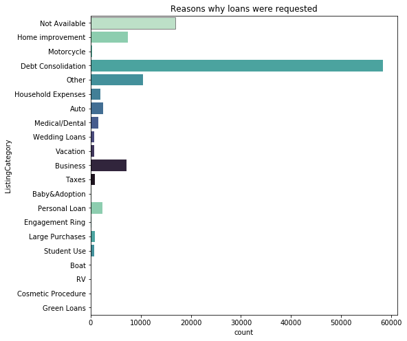

```python
mycolor = sb.color_palette("mako_r",n_colors=12)
plt.figure(figsize=[8,8])

sb.countplot(data=loandata_clean, y='ListingCategory', palette=mycolor, edgecolor='gray');
plt.title('Reasons why loans were requested')
```

A Term could be 12 months(1 year), 36 months(3 years) or 60 months(5 years) and this is the length of time a borrower takes to repay their loan. **What is the most frequently used Term?**

```
Text(0.5,1,'Loan Term')
```

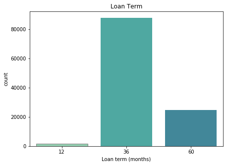

```python
plt.figure(figsize=[7,5])
mycolor = sb.color_palette("mako_r")

sb.countplot(data = loandata_clean, x='Term',palette=mycolor, edgecolor='gray')
plt.xlabel('Loan term (months)')
plt.title('Loan Term')
```

Most borrowers opt for the 36 months (3 years) option in order to repay their loan

In this loan system where investors fund the loan directly let us explore how they invest. Let us explore and see **how many investors usually fund a loan?**

```python
np.log10(loandata_clean['Investors'].describe())
```

```
count    5.056665
mean     1.905662
std      2.013844
min      0.000000
25%      0.301030
50%      1.643453
75%      2.060698
max      3.075182
Name: Investors, dtype: float64
```

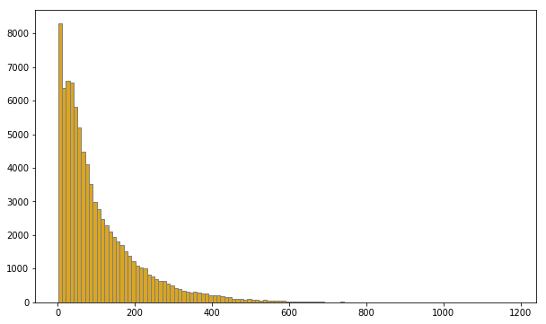

```python
plt.figure(figsize=[10,6])
x='Investors'
bin_edges = np.arange(1.5,1189.5+1,10)
bins=bin_edges

histplot(x,bins,lw=2)
```

The LenderYield is the interest rate less the servicing fee. Here we **explore and see the distribution of LenderYield**

```
Text(0.5,1,'Distibution of LenderYield')
```

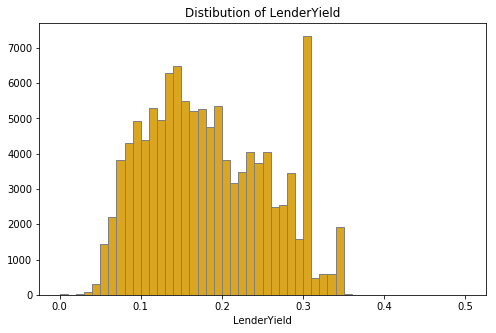

```python
#start with a standard plot
binsize = 0.01
bins = np.arange(0, loandata_clean['LenderYield'].max()+binsize, binsize)
plt.figure(figsize=[8,5])
x='LenderYield'

histplot(x,bins)

plt.xlabel( 'LenderYield')
plt.title('Distibution of LenderYield')
```

### Discuss the distribution(s) of your variable(s) of interest. Were there any unusual points? Did you need to perform any transformations?

The Loan Original Amount distribution was somewhat skewed so I transformed the data using log which gave me a more interpretable result. The investors variable is skewed to the right with a long tail but is clearly readable. The most interesting finding so far is that people borrow to pay off debts.

## Bivariate Exploration

```python
# Function to create reg plot
def reggrid(x, y, **kwargs):
    sb.regplot(data = loandata_clean, x = x,y = y,color="teal", truncate=False, x_jitter=0.3, scatter_kws={'alpha':1/15});
```

Delinquency means you are behind on payment. Here we explore **if the Amount loaned has any effect on the borrower's delinquency**

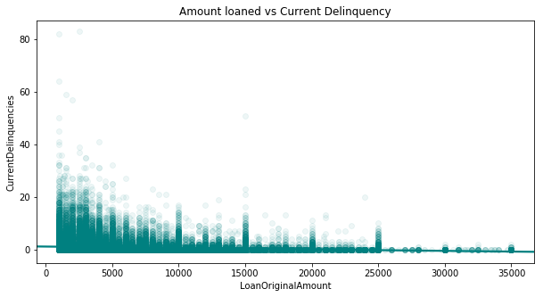

```python
plt.figure(figsize=[10,5])
x='LoanOriginalAmount'
y='CurrentDelinquencies'
reggrid(x,y)
plt.title('Amount loaned vs Current Delinquency');
```

The result shows a higher concentration of deliquencies for loan amounts between \$1,000 to \\$10,000. As we explore further we would see the relationship with their employment status.

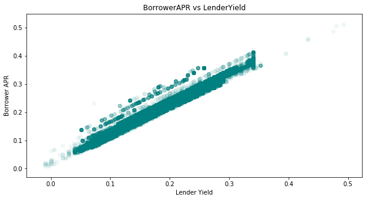

```python
plt.figure(figsize=[10,5])
plt.scatter(data = loandata_clean, y = 'BorrowerAPR', x = 'LenderYield',color="teal",alpha=1/20);
plt.xlabel('Lender Yield')
plt.ylabel('Borrower APR')
plt.title('BorrowerAPR vs LenderYield');
```

Above the scatter plot show quite a proportional relationship between the BorrowerAPR and LenderYield that is a high APR begets high LenderYield

From the univariate exploration, we see that most of the borrowers are employed and the Original Loan Amount peaks at about 4,500 followed by 11,000 and the 15,000. **Do income range or employment status have an impact on the amount borrowed?**

```
Text(0.5,1,'Loan by IncomeRange')
```

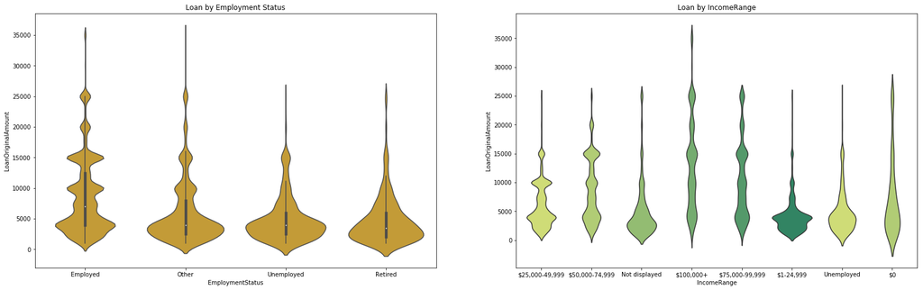

```python
#plot employer status by loan original amount and also against income range
plt.figure(figsize = [27,8])
mycolor = sb.color_palette("summer_r")

plt.subplot(1,2,1)
sb.violinplot(data=loandata_clean, x='EmploymentStatus', y='LoanOriginalAmount',color="goldenrod",edge="gray")
plt.title('Loan by Employment Status')

plt.subplot(1,2,2)
sb.violinplot(data=loandata_clean, x='IncomeRange', y='LoanOriginalAmount',inner=None,palette=mycolor, edge="gray")
plt.title('Loan by IncomeRange')
```

First thing noticed is that the retired people keep it low - their loan amount is below \$5,000. The same applies to the unemployed though they have more people borrowing between \\$10,000 to \$15,000. Others have a high concentration of loan amounts less than \\$5,000 but we also see a few others borrowing up to \$25,000 with the numbers reducing as the amount increases. The employed have the most varied loan amounts and is the only group with mean LoanOriginalAmount above \\$5000. This result shows that the employment status has an impact on the amount borrowed. From the income range, it is clear that the higher the income range, the higher amount borrowed.

**Can the income range affect the borrower APR?**

```
Text(0.5,1,'BorrowerAPR by IncomeRange')
```

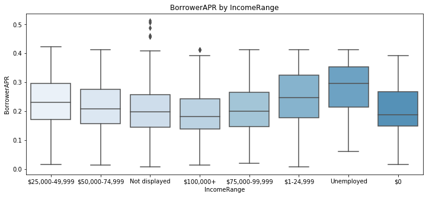

```python
#income range vs borrowerAPR
mycolor = sb.color_palette("Blues",n_colors=12)
plt.figure(figsize = [12,5])
sb.boxplot(data=loandata_clean, x='IncomeRange', y='BorrowerAPR',palette=mycolor)
plt.title('BorrowerAPR by IncomeRange')
```

The central line shows the median value. From the chart it is clear that people who earn the most, have the lowest median Borrower annual percentage rate but what could have influenced this result? a longer loan term or higher amount borrowed? This would be explored ahead.

```
Text(0.5,1,'Borrower Rate by Prosper score')
```

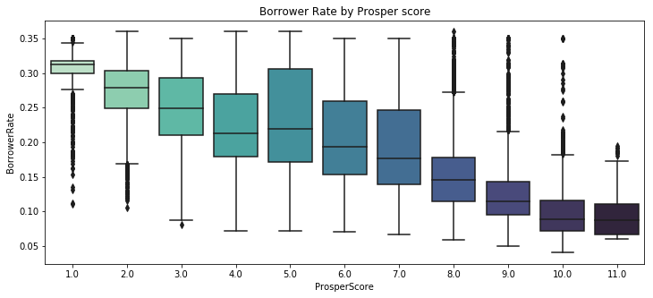

```python
plt.figure(figsize = [12,5])
mycolor = sb.color_palette("mako_r",n_colors=12)
sb.boxplot(data=loandata_clean, x='ProsperScore', y='BorrowerRate',palette=mycolor)
plt.title('Borrower Rate by Prosper score')
```

The results show that the less risk a borrower poses (that is the higher their credit score), the less their interest rate. Perhaps this could be influenced by the investors confidence in the loan being repayed without default.

**Let us explore the correlations of some numeric and categorical variables**

```python
numeric_vars = ['LoanOriginalAmount', 'BorrowerAPR','Investors','LenderYield','StatedMonthlyIncome','Term','ListingCategory (numeric)']
categoric_vars = ['EmploymentStatus','IncomeRange','LoanRating']
```

```
Text(0.5,1,'Correlation Chart')
```

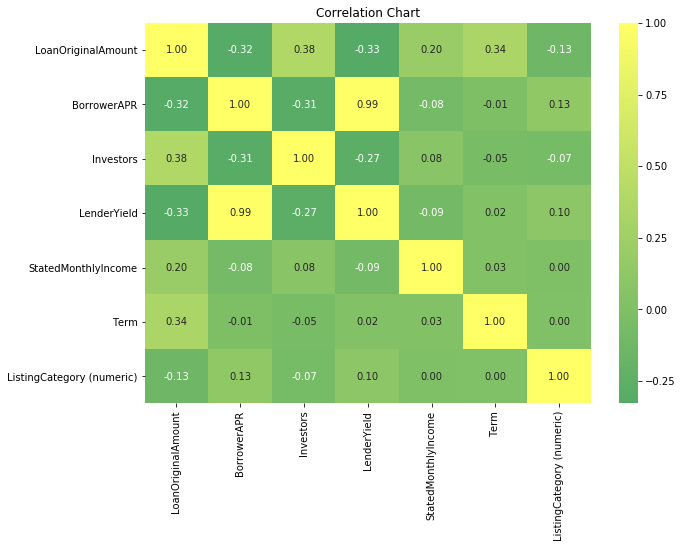

```python
#correlation plot
plt.figure(figsize=[10,7])
sb.heatmap(loandata_clean[numeric_vars].corr(),annot=True, fmt='.2f',
           cmap = 'summer', center = 0)
plt.title('Correlation Chart')
```

```
loandata_clean.shape= (113937, 74)
loandata_samp.shape= (500, 74)
```

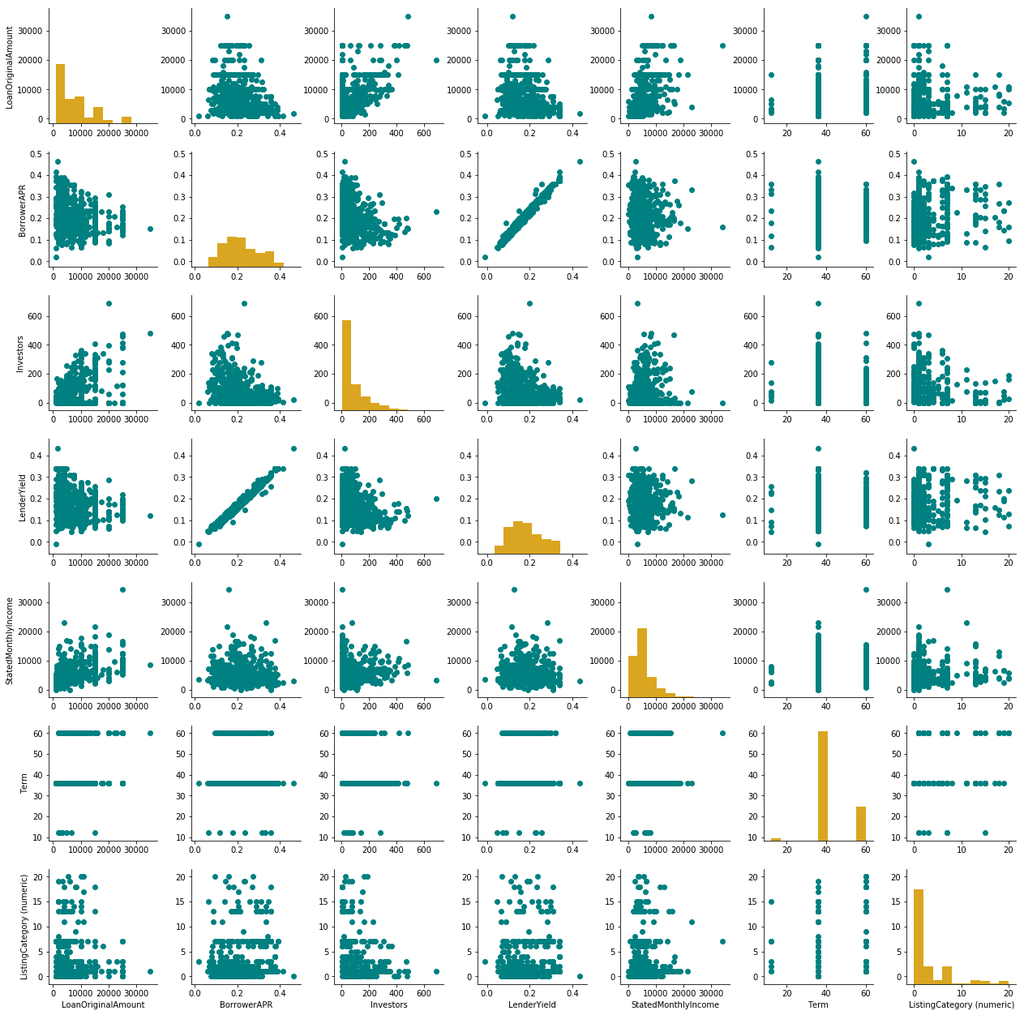

```python
# plot matrix: sample 500 variables
print("loandata_clean.shape=",loandata_clean.shape)
loandata_samp = loandata_clean.sample(n=500, replace = False)
print("loandata_samp.shape=",loandata_samp.shape)
mycolor = sb.color_palette("mako_r",n_colors=12)

g = sb.PairGrid(data = loandata_samp, vars = numeric_vars)
g = g.map_diag(plt.hist, bins = 10,color="goldenrod");
g.map_offdiag(plt.scatter,color="teal")
```

The highest correlation is between the BorrowerAPR and LenderYield which is not a suprising result as both are directly proportional to each other. The strongest negative correlation is between lender yield and loan original amount. One interesting finding here is the correlation between Investors and StatedMonthlyIncome, one would think that the monthly income would determine an investors interest but that is clearly not the case.

**Explore the individual ListingCategories against LoanOrignalAmount**

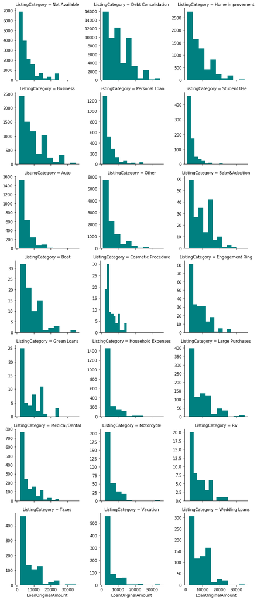

```python
#here we measure the individual listing categories against LoanOriginalAmount
loan_use = ['Not Available','Debt Consolidation','Home improvement','Business','Personal Loan','Student Use','Auto',
           'Other','Baby&Adoption','Boat','Cosmetic Procedure','Engagement Ring','Green Loans','Household Expenses',
           'Large Purchases','Medical/Dental','Motorcycle','RV','Taxes','Vacation','Wedding Loans']

mycolor = sb.color_palette("mako_r",n_colors=12)

listings = pd.api.types.CategoricalDtype(ordered=True, categories=loan_use)
loandata_clean['ListingCategory'] = loandata_clean['ListingCategory'].astype(listings);

# Plot the Seaborn's FacetGrid
g = sb.FacetGrid(data = loandata_clean, col = 'ListingCategory', col_wrap=3, sharey=False, margin_titles=True)
g.map(plt.hist, "LoanOriginalAmount", color="teal")
```

Above we have subplots of each listing and there we see the distribution of loan amount for each of the listing categories. Most of the loan amounts fall within \$0-10000. It is worth noting that again, Debt Consolidation tops the list of reason for loan.

### Talk about some of the relationships you observed in this part of the investigation. How did the feature(s) of interest vary with other features in the dataset?

You find that most of the delinquincies are within the lowband of loan amount less that \$10,000. Now moving to the salary range and employment status, you also find that the unemployed, retired and "other" usually borrow within that rate of less than \\$10,000. Perhaps the slow influx or lack of income is the reason they are mostly behind on payments.

### Did you observe any interesting relationships between the other features (not the main feature(s) of interest)?

One interesting discovery here is the lack of correlation between monthly income and investors. One would think the investors would lend based on tangible evidence(income) that their loan can be repaid but that is not the case. Another interesting discovery is that between prosper score and borrower rate, those with high prosper score (they offer lower risk) have a low interest rate on their loans.

## Multivariate Exploration

The Borrower APR is the annual % rate the borrower pays/ought to pay until their term is over. **Does this have any relationship with their income rate and Loan original amount?**

```
Text(0.5,1,'Relationship between IncomeRange and BorrowerAPR')
```

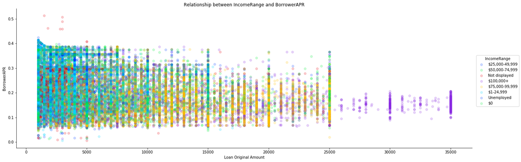

```python
g= sb.FacetGrid(data = loandata_clean, hue = 'IncomeRange', size=6, aspect=3, palette ='bright')
g.map(sb.regplot, 'LoanOriginalAmount', 'BorrowerAPR', x_jitter = 0.02,scatter_kws={'alpha':1/5}, fit_reg = False)
g.add_legend()
plt.xlabel('Loan Original Amount')
plt.ylabel('BorrowerAPR')
plt.title('Relationship between IncomeRange and BorrowerAPR')
```

From the plot there's quite some diversity but it is clear that those within the income range of \$100,000+ not only take high amount of loan but they also enjoy low BorrowerAPR. You also find that the blue color which represents those that earn between \\$25,000-49,999, are more concentrated between \$0-10,000 loan amount. Indeed, the income influences the amount borrowed.

**Could investors be more interested in employment status as well as length of loan term?**

```
Text(0.5,1,'Loan Term by Employment Status')
```

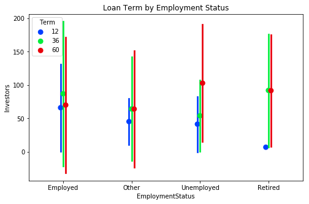

```python
mycolor = sb.color_palette("bright",n_colors=3)
plt.figure(figsize=[8,5])
sb.pointplot(data=loandata_clean, x = 'EmploymentStatus', y='Investors',hue='Term',ci='sd',linestyles="",dodge=True, palette=mycolor);
plt.title('Loan Term by Employment Status')
```

Here we see how the investors invest in the different employment status groups with the dot showing the concentration of investors.

```python
#create a new column by extracting the year from the loanoriginationdatecolumn
loandata_clean['LoanYear'] = pd.DatetimeIndex(loandata_clean['LoanOriginationDate']).year
```

```python
#create subset of Terms
oneyr=loandata_clean[loandata_clean['Term']==12]
threeyrs=loandata_clean[loandata_clean['Term']==36]
fiveyrs=loandata_clean[loandata_clean['Term']==60]
```

```
Text(0.5,1,'Duration of loan across the years')
```

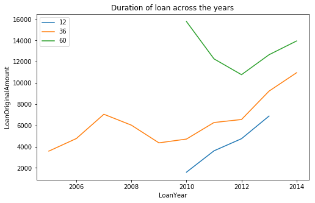

```python
#plot graph of term
plt.figure(figsize=[8,5])
oneyr.groupby('LoanYear')['LoanOriginalAmount'].mean().plot(kind='line', label='12')
threeyrs.groupby('LoanYear')['LoanOriginalAmount'].mean().plot(kind='line', label='36')
fiveyrs.groupby('LoanYear')['LoanOriginalAmount'].mean().plot(kind='line', label='60')
plt.xlabel('LoanYear')
plt.ylabel('LoanOriginalAmount')
plt.legend()
plt.title('Duration of loan across the years')
```

**Finally let us view explore individual listing catergories on Delinquencies against loan amounts**

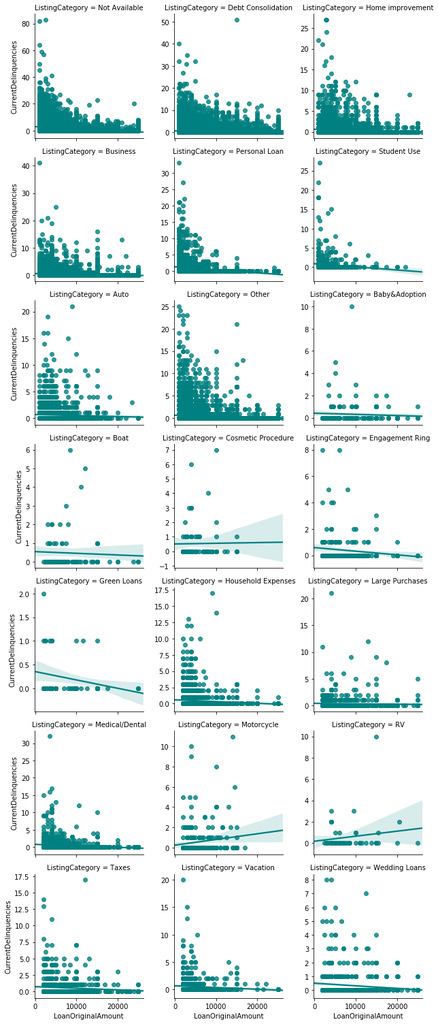

```python
# Plot the Seaborn's FacetGrid
g = sb.FacetGrid(data = loandata_clean, col = 'ListingCategory', col_wrap=3, sharey=False, margin_titles=True)
g.map(sb.regplot,"LoanOriginalAmount","CurrentDelinquencies",color='teal')
```

### Talk about some of the relationships you observed in this part of the investigation. Were there features that strengthened each other in terms of looking at your feature(s) of interest?

Most people who take loans between \$4,000-12,000 prefer the 36 months(3 years) term to pay back the loans

### Were there any interesting or surprising interactions between features?

Debt consolidation appears to have quite a number of delinquencies but this is not too suprising since they took this loan to service a debt they may need to take another to service this debt. Though thr most interesting factor there is that compared to others, the delinquencies spread to amounts over \$20,000 and most of the borrowers of such amounts are employed and earn above \\$50,000.